# Reproducible Manuscript Outputs

Christopher Odoom

2026-05-28

## Purpose

This R Markdown file reproduces the main manuscript outputs from the source data: analytic tables, workflow and result figures, cutoff calibration, and exported figure/table files.

## Packages

```r
library(dplyr)
library(ggplot2)
library(haven)
library(knitr)
library(patchwork)
library(purrr)
library(readr)
library(scales)
library(survey)
library(tidyr)
```

```r
options(survey.lonely.psu = "adjust")
```

## Load And Prepare Data

```r
sedentary_hip_df <- read_csv("data/nosleep_data.csv.gz", show_col_types = FALSE)
sedentary_wrist_df <- read_csv("data/wrist_df.csv.gz", show_col_types = FALSE)
sleep_df <- read_csv("data/sleep_est_data.csv.gz", show_col_types = FALSE)
```

```r
sedentary_hip_df <- sedentary_hip_df %>%
  rename(
    Day = Date,
    percent_sedentary_hip = PercentSedentary
  ) %>%
  filter(PartialDay != "Yes") %>%
  mutate(
    Exam_weight_recal = 0.5 * Exam_weight,
    Dataset = if_else(Dataset == "2011-12", "2011-2012", "2013-2014")
  )

sedentary_wrist_df <- sedentary_wrist_df %>%
  rename(percent_sedentary_wrist = percent_sitting) %>%
  select(ID, Day, Hour, percent_sedentary_wrist)

sleep_df <- sleep_df %>%
  transmute(
    ID,
    Day,
    Hour,
    percent_sleep = percent_sleep_nonwear
  )

sedentary_df <- inner_join(
  x = sedentary_wrist_df,
  y = sedentary_hip_df,
  by = c("ID", "Day", "Hour")
)

sleep_sed_df <- inner_join(
  x = sedentary_df,
  y = sleep_df,
  by = c("ID", "Day", "Hour")
)

demo_unique <- sedentary_df %>%
  mutate(
    Age_group = case_when(
      Age < 18 ~ "<18",
      Age <= 34 ~ "18-34",
      Age <= 44 ~ "35-44",
      Age <= 64 ~ "45-64",
      TRUE ~ ">=65"
    ),
    BMI = Weight / (Height / 100)^2,
    BMI_cat = case_when(
      BMI < 25 ~ "under/normal weight",
      BMI < 30 ~ "over weight",
      TRUE ~ "obesity"
    )
  ) %>%
  group_by(ID) %>%
  summarise(
    Age_group = first(Age_group),
    BMI_cat = first(BMI_cat),
    Race = first(Race),
    Gender = first(Gender),
    Education = first(Education_coarse),
    Marital_status = first(Marital_status),
    Exam_weight_recal = first(Exam_weight_recal),
    PSU = first(PSU),
    Stratum = first(Stratum),
    Dataset = first(Dataset),
    .groups = "drop"
  )
```

## Reusable Functions

```r
compute_sedentary_by_cutoff <- function(df, cutoffs) {
  id_days <- distinct(df, ID, Day)

  map_dfr(cutoffs, function(cut) {
    df %>%
      filter(percent_sleep < cut) %>%
      group_by(ID, Day) %>%
      summarise(
        total_sed_hours = sum(percent_sedentary_wrist / 100, na.rm = TRUE),
        n_hours = n(),
        .groups = "drop"
      ) %>%
      right_join(id_days, by = c("ID", "Day")) %>%
      mutate(
        total_sed_hours = replace_na(total_sed_hours, 0),
        n_hours = replace_na(n_hours, 0),
        sleep_hrs = 24 - n_hours,
        cutoff = cut
      )
  })
}

get_svy_estimates <- function(data_cut) {
  des <- svydesign(
    id = ~PSU,
    strata = ~Stratum,
    weights = ~Exam_weight_recal,
    nest = TRUE,
    data = data_cut
  )

  sleep_est <- svymean(~mean_sleep_hours, des, na.rm = TRUE)
  sed_est <- svymean(~mean_sed_hours, des, na.rm = TRUE)

  tibble(
    cutoff = unique(data_cut$cutoff),
    sleep_mean = coef(sleep_est)[1],
    sleep_se = SE(sleep_est)[1],
    sed_mean = coef(sed_est)[1],
    sed_se = SE(sed_est)[1]
  )
}

format_mean_ci <- function(design_obj, variable = "mean_sed_hours", digits = 2) {
  m <- svymean(as.formula(paste0("~", variable)), design_obj, na.rm = TRUE)
  ci <- confint(m)
  sprintf(
    paste0("%.", digits, "f (%.", digits, "f, %.", digits, "f)"),
    coef(m)[1],
    ci[1, 1],
    ci[1, 2]
  )
}

format_n_pct <- function(df, denominator) {
  n <- n_distinct(df$ID)
  sprintf("%s (%.1f%%)", comma(n), 100 * n / denominator)
}
```

## Table 1

Table 1. Analytic sample and wear-day distribution by NHANES cycle (2011-2014)

```r
df_days <- sleep_sed_df %>%
  distinct(ID, Day, Dataset) %>%
  group_by(ID, Dataset) %>%
  summarise(n_days = n(), .groups = "drop")

table_by_cycle <- df_days %>%
  count(Dataset, n_days, name = "n") %>%
  group_by(Dataset) %>%
  mutate(
    percent = 100 * n / sum(n),
    value = paste0(comma(n), " (", round(percent, 1), ")")
  ) %>%
  ungroup() %>%
  select(n_days, Dataset, value) %>%
  pivot_wider(names_from = Dataset, values_from = value)

table_total <- df_days %>%
  count(n_days, name = "n") %>%
  mutate(
    percent = 100 * n / sum(n),
    `Total (2011-14)` = paste0(comma(n), " (", round(percent, 1), ")")
  ) %>%
  select(n_days, `Total (2011-14)`)

table1 <- table_by_cycle %>%
  left_join(table_total, by = "n_days") %>%
  arrange(n_days) %>%
  mutate(n_days = as.character(n_days))

sample_row <- df_days %>%
  group_by(Dataset) %>%
  summarise(n = n(), .groups = "drop") %>%
  mutate(value = paste0(comma(n), " (100.0)")) %>%
  select(Dataset, value) %>%
  pivot_wider(names_from = Dataset, values_from = value) %>%
  mutate(
    n_days = "Sample Analyzed (1-7)",
    `Total (2011-14)` = paste0(comma(nrow(df_days)), " (100.0)")
  )

table1 <- bind_rows(table1, sample_row) %>%
  select(
    `Full days` = n_days,
    `2011-2012`,
    `2013-2014`,
    `Total (2011-14)`
  )

write_csv(table1, "outputs/table1_wear_day_distribution.csv")

kable(
  table1,
  caption = "Table 1. Analytic sample and wear-day distribution by NHANES cycle (2011-2014)."
)
```

Table 1. Analytic sample and wear-day distribution by NHANES cycle (2011-2014).

| Full days | 2011-2012 | 2013-2014 | Total (2011-14) |
| --- | --- | --- | --- |
| 1 | 29 (0.4) | 29 (0.4) | 58 (0.4) |
| 2 | 37 (0.5) | 31 (0.4) | 68 (0.5) |
| 3 | 48 (0.7) | 30 (0.4) | 78 (0.5) |
| 4 | 37 (0.5) | 31 (0.4) | 68 (0.5) |
| 5 | 56 (0.8) | 30 (0.4) | 86 (0.6) |
| 6 | 68 (1) | 43 (0.6) | 111 (0.8) |
| 7 | 6,568 (96) | 7,497 (97.5) | 14,065 (96.8) |
| Sample Analyzed (1-7) | 6,843 (100.0) | 7,691 (100.0) | 14,534 (100.0) |

Notes: A full day is a 24-hour day with 24 hourly records; partial initiation/return days are excluded.

## Cutoff Calibration Data

```r
cutoffs <- seq(25, 100, 1)
sed_all <- compute_sedentary_by_cutoff(sleep_sed_df, cutoffs)

df_person <- sed_all %>%
  group_by(ID, cutoff) %>%
  summarise(
    mean_sed_hours = mean(total_sed_hours, na.rm = TRUE),
    mean_sleep_hours = mean(sleep_hrs, na.rm = TRUE),
    .groups = "drop"
  )

model_df <- df_person %>%
  left_join(demo_unique, by = "ID") %>%
  filter(
    !is.na(Exam_weight_recal),
    !is.na(PSU),
    !is.na(Stratum)
  )

results <- model_df %>%
  group_split(cutoff) %>%
  map_dfr(get_svy_estimates)
```

```r
sleep_2011_12 <- read_xpt("data/self-sleep-2011-12.xpt")
sleep_2013_14 <- read_xpt("data/self-sleep-2013-14.xpt")

self_sleep <- bind_rows(sleep_2011_12, sleep_2013_14) %>%
  transmute(
    ID = SEQN,
    self_reported_slp_hrs = SLD010H
  ) %>%
  filter(
    !is.na(self_reported_slp_hrs),
    !(self_reported_slp_hrs %in% c(77, 99))
  )

self_sleep_weighted <- self_sleep %>%
  left_join(
    demo_unique %>% select(ID, Exam_weight_recal, PSU, Stratum),
    by = "ID"
  ) %>%
  filter(!is.na(Exam_weight_recal))

des_self_sleep <- svydesign(
  id = ~PSU,
  strata = ~Stratum,
  weights = ~Exam_weight_recal,
  nest = TRUE,
  data = self_sleep_weighted
)

mean_self_sleep <- svymean(~self_reported_slp_hrs, design = des_self_sleep, na.rm = TRUE)
self_sleep_mean <- as.numeric(coef(mean_self_sleep)[1])
self_sleep_ci <- as.numeric(confint(mean_self_sleep)[1, ])

best_cutoff <- results %>%
  mutate(diff = abs(sleep_mean - self_sleep_mean)) %>%
  slice_min(diff, n = 1, with_ties = FALSE)

selected_cutoff <- as.numeric(best_cutoff$cutoff[1])
selected_cutoff
```

```
## [1] 91
```

## Main Analytic Dataset At Selected Cutoff

```r
model_df_91 <- model_df %>%
  filter(cutoff == selected_cutoff)

des91 <- svydesign(
  id = ~PSU,
  strata = ~Stratum,
  weights = ~Exam_weight_recal,
  nest = TRUE,
  data = model_df_91
)

overall_sed <- svymean(~mean_sed_hours, des91, na.rm = TRUE)
overall_sed_ci <- confint(overall_sed)
overall_sed
```

```
##                  mean     SE
## mean_sed_hours 11.351 0.0443
```

```r
overall_sed_ci
```

```
##                   2.5 %   97.5 %
## mean_sed_hours 11.26453 11.43807
```

```r
sleep_aware_hourly_df <- sleep_sed_df %>%
  filter(percent_sleep < selected_cutoff)
```

## Figure 1

Figure 1. Workflow for deriving hourly sitting and sleep summaries. (A) Raw 80 Hz accelerometer signal. (B) CHAP sitting predictions and SWaN sleep/wake/non-wear classifications. (C) Hourly sitting and sleep/non-wear percentages used to define waking sedentary time under candidate sleep cutoffs.

```r
source("R/make_preprocessing_workflow_figure.R")
```

```
## Wrote /Users/christopherodoom/Desktop/PhD_program/Research_Work/pctSitting_research/figures/preprocessing_workflow_figure.png
## Wrote /Users/christopherodoom/Desktop/PhD_program/Research_Work/pctSitting_research/figures/preprocessing_workflow_figure.pdf
## Wrote /Users/christopherodoom/Desktop/PhD_program/Research_Work/pctSitting_research/figures/preprocessing_workflow_figure_three_panel.png
## Wrote /Users/christopherodoom/Desktop/PhD_program/Research_Work/pctSitting_research/figures/preprocessing_workflow_figure_three_panel.pdf
## Wrote /Users/christopherodoom/Desktop/PhD_program/Research_Work/pctSitting_research/figures/fig1.png
## Wrote /Users/christopherodoom/Desktop/PhD_program/Research_Work/pctSitting_research/figures/fig1.pdf
```

```r
knitr::include_graphics("figures/fig1.png")
```

[figure not shown]

Figure 1. Workflow for deriving hourly sitting and sleep summaries. (A) Raw 80 Hz accelerometer signal. (B) CHAP sitting predictions and SWaN sleep/wake/non-wear classifications. (C) Hourly sitting and sleep/non-wear percentages used to define waking sedentary time under candidate sleep cutoffs.

## Table 2

Table 2. Comparison of sedentary time estimates across studies by measurement method, datasets, and population.

```r
table2 <- tibble::tribble(
  ~Paper, ~`Method (Dataset & Population)`, ~`Estimate (hours/day)`, ~Notes,
  "This study",
  "Dataset: NHANES 2011-2014, wrist-worn 80 Hz accelerometer dataset. U.S. population: 14,534 participants, aged 3+ years. Method: CHAP posture model and SWaN sleep model.",
  "11.35",
  "Uses machine learning to directly estimate sitting probability. Calibrated to match mean self-reported sleep duration.",
  "Matthews et al. (2008)",
  "Dataset: NHANES 2003-2004, hip-worn ActiGraph minute-level accelerometer dataset. U.S. population: 6,329 participants, aged 6+ years. Method: intensity threshold of <100 cpm.",
  "7.7",
  "Represents 54.9% of monitored time. Non-wear time was excluded and average monitor wear time was 13.9 hours/day.",
  "Yang et al. (2019)",
  "Dataset: NHANES 2001-2016. U.S. population: children, adolescents, and adults. Method: self-reported total sitting time questionnaire.",
  "~6.4 adults; 8.2 adolescents",
  "Adult estimate reflects the 2015-2016 cycle; sitting time increased over time in the questionnaire data."
)

write_csv(table2, "outputs/table2_study_comparison.csv")

kable(
  table2,
  caption = "Table 2. Comparison of sedentary time estimates across studies by measurement method, datasets, and population."
)
```

Table 2. Comparison of sedentary time estimates across studies by measurement method, datasets, and population.

| Paper | Method (Dataset & Population) | Estimate (hours/day) | Notes |
| --- | --- | --- | --- |
| This study | Dataset: NHANES 2011-2014, wrist-worn 80 Hz accelerometer dataset. U.S. population: 14,534 participants, aged 3+ years. Method: CHAP posture model and SWaN sleep model. | 11.35 | Uses machine learning to directly estimate sitting probability. Calibrated to match mean self-reported sleep duration. |
| Matthews et al. (2008) | Dataset: NHANES 2003-2004, hip-worn ActiGraph minute-level accelerometer dataset. U.S. population: 6,329 participants, aged 6+ years. Method: intensity threshold of <100 cpm. | 7.7 | Represents 54.9% of monitored time. Non-wear time was excluded and average monitor wear time was 13.9 hours/day. |
| Yang et al. (2019) | Dataset: NHANES 2001-2016. U.S. population: children, adolescents, and adults. Method: self-reported total sitting time questionnaire. | ~6.4 adults; 8.2 adolescents | Adult estimate reflects the 2015-2016 cycle; sitting time increased over time in the questionnaire data. |

## Figure 2

Figure 2. Survey-weighted hourly patterns of wrist-derived sedentary behavior by day type before and after sleep exclusion. Panel A shows CHAP-predicted sitting time including sleep periods; Panel B shows waking sedentary time after excluding hours with >=91% sleep/nonwear. Lines represent hourly means and shaded bands indicate 95% confidence intervals.

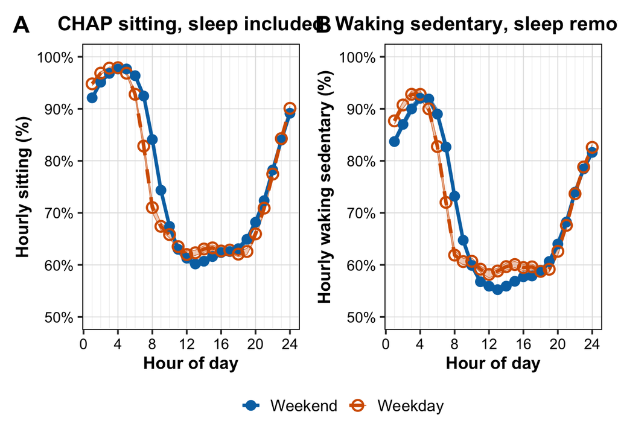

Figure 2. Survey-weighted hourly patterns of wrist-derived sedentary behavior by day type before and after sleep exclusion. Panel A shows CHAP-predicted sitting time including sleep periods; Panel B shows waking sedentary time after excluding hours with >=91% sleep/nonwear. Lines represent hourly means and shaded bands indicate 95% confidence intervals.

```r
make_hourly_daytype_plot <- function(df, yvar, ylab, title_label, y_limits) {
  df <- df %>%
    mutate(DayType = factor(DayType, levels = c("Weekend", "Weekday")))

  des <- svydesign(
    id = ~PSU,
    strata = ~Stratum,
    weights = ~Exam_weight_recal,
    nest = TRUE,
    data = df
  )

  hourly_est <- svyby(
    as.formula(paste0("~", yvar)),
    by = ~DayType + Hour,
    design = des,
    FUN = svymean,
    vartype = "ci",
    na.rm = TRUE
  ) %>%
    rename(estimate = !!sym(yvar))

  daytype_colors <- c("Weekend" = "#0072B2", "Weekday" = "#D55E00")

  ggplot(hourly_est, aes(x = Hour, y = estimate, group = DayType)) +
    geom_ribbon(aes(ymin = ci_l, ymax = ci_u, fill = DayType), alpha = 0.28, color = NA) +
    geom_line(aes(y = ci_l, color = DayType), linewidth = 0.35, alpha = 0.65) +
    geom_line(aes(y = ci_u, color = DayType), linewidth = 0.35, alpha = 0.65) +
    geom_line(aes(color = DayType, linetype = DayType), linewidth = 1.35) +
    geom_point(aes(color = DayType, shape = DayType), size = 3.3, stroke = 1.25, fill = "white") +
    scale_color_manual(values = daytype_colors) +
    scale_fill_manual(values = daytype_colors) +
    scale_linetype_manual(values = c("Weekend" = "solid", "Weekday" = "dashed")) +
    scale_shape_manual(values = c("Weekend" = 16, "Weekday" = 1)) +
    scale_x_continuous(breaks = seq(0, 24, 4), minor_breaks = seq(1, 24, 1), limits = c(1, 24)) +
    scale_y_continuous(
      limits = y_limits,
      labels = percent_format(scale = 1),
      breaks = seq(y_limits[1], y_limits[2], 10)
    ) +
    labs(x = "Hour of day", y = ylab, title = title_label, color = NULL, fill = NULL, linetype = NULL, shape = NULL) +
    guides(fill = "none") +
    theme_bw(base_size = 15) +
    theme(
      plot.title = element_text(face = "bold", size = 16, hjust = 0.5, margin = margin(b = 8)),
      axis.title = element_text(face = "bold", size = 14),
      axis.text = element_text(color = "black", size = 12),
      panel.grid.major = element_line(color = "grey88", linewidth = 0.35),
      panel.grid.minor.x = element_line(color = "grey94", linewidth = 0.25),
      panel.grid.minor.y = element_blank(),
      panel.border = element_rect(color = "black", linewidth = 0.7),
      legend.position = "bottom",
      legend.text = element_text(size = 13)
    )
}

p_left <- make_hourly_daytype_plot(
  df = sleep_sed_df,
  yvar = "percent_sedentary_wrist",
  ylab = "Hourly sitting (%)",
  title_label = "CHAP sitting, sleep included",
  y_limits = c(50, 100)
) +
  labs(tag = "A")

p_right <- make_hourly_daytype_plot(
  df = sleep_aware_hourly_df,
  yvar = "percent_sedentary_wrist",
  ylab = "Hourly waking sedentary (%)",
  title_label = "Waking sedentary, sleep removed",
  y_limits = c(50, 100)
) +
  labs(tag = "B")

figure2 <- p_left + p_right +
  plot_layout(guides = "collect", widths = c(1, 1)) &
  theme(
    legend.position = "bottom",
    plot.tag = element_text(face = "bold", size = 19),
    plot.tag.position = c(0.02, 0.98)
  )

ggsave("figures/figure2_hourly_daytype.png", figure2, width = 10, height = 5.8, units = "in", dpi = 600, bg = "white")
ggsave("figures/figure2_hourly_daytype.pdf", figure2, width = 10, height = 5.8, units = "in", bg = "white")
```

## Figure 3

Figure 3. Distribution of participants by mean daily waking sedentary time and corresponding 24-hour behavioral composition. Panel A shows the proportion and unweighted number of participants in each sedentary-time category. Panel B shows the mean daily allocation to sedentary time, sleep/nonwear, and other waking time within each category.

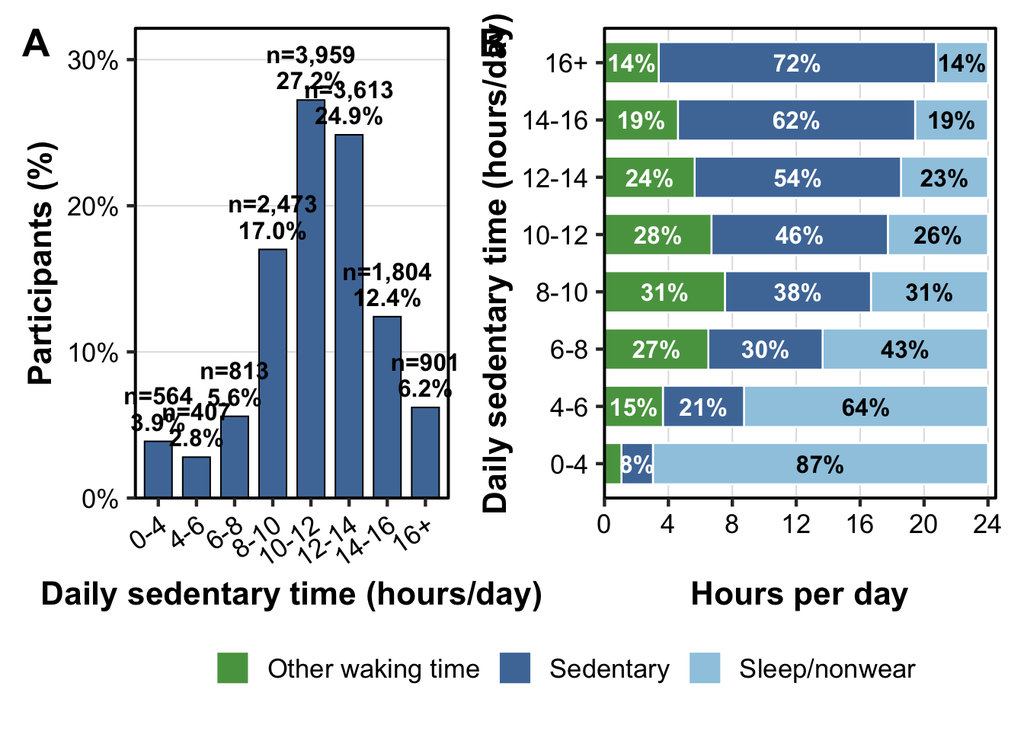

Figure 3. Distribution of participants by mean daily waking sedentary time and corresponding 24-hour behavioral composition. Panel A shows the proportion and unweighted number of participants in each sedentary-time category. Panel B shows the mean daily allocation to sedentary time, sleep/nonwear, and other waking time within each category.

```r
df_plot <- model_df_91 %>%
  distinct(ID, .keep_all = TRUE) %>%
  mutate(
    sed_bin = cut(
      mean_sed_hours,
      breaks = c(0, 4, seq(6, 16, by = 2), Inf),
      labels = c("0-4", "4-6", "6-8", "8-10", "10-12", "12-14", "14-16", "16+"),
      include.lowest = TRUE,
      right = FALSE
    )
  ) %>%
  filter(!is.na(sed_bin))

plot_df <- df_plot %>%
  group_by(sed_bin) %>%
  summarise(
    n = n_distinct(ID),
    prop = n / n_distinct(df_plot$ID),
    .groups = "drop"
  ) %>%
  mutate(label = paste0("n=", comma(n), "\n", percent(prop, accuracy = 0.1)))

left_plot <- ggplot(plot_df, aes(x = sed_bin, y = prop)) +
  geom_col(width = 0.72, fill = "#4E79A7", color = "black", linewidth = 0.35) +
  geom_text(aes(label = label), vjust = -0.25, size = 4.2, fontface = "bold", lineheight = 0.9) +
  scale_y_continuous(labels = percent_format(accuracy = 1), expand = expansion(mult = c(0, 0.18))) +
  labs(x = "Daily sedentary time (hours/day)", y = "Participants (%)", tag = "A") +
  coord_cartesian(clip = "off") +
  theme_bw(base_size = 17) +
  theme(
    axis.title = element_text(face = "bold", size = 16),
    axis.text = element_text(color = "black", size = 13),
    axis.text.x = element_text(angle = 35, hjust = 1, vjust = 1),
    panel.grid.major.x = element_blank(),
    panel.grid.major.y = element_line(color = "grey88", linewidth = 0.35),
    panel.grid.minor = element_blank(),
    panel.border = element_rect(color = "black", linewidth = 0.7)
  )

right_df <- df_plot %>%
  group_by(sed_bin) %>%
  summarise(
    Sedentary = mean(mean_sed_hours, na.rm = TRUE),
    `Sleep/nonwear` = mean(mean_sleep_hours, na.rm = TRUE),
    `Other waking time` = mean(24 - mean_sed_hours - mean_sleep_hours, na.rm = TRUE),
    .groups = "drop"
  )

right_df_long <- right_df %>%
  pivot_longer(cols = c(`Sleep/nonwear`, Sedentary, `Other waking time`), names_to = "behavior", values_to = "hours") %>%
  mutate(
    behavior = factor(behavior, levels = c("Sleep/nonwear", "Sedentary", "Other waking time")),
    percent_day = hours / 24
  )

right_label_df <- right_df %>%
  pivot_longer(cols = c(`Other waking time`, Sedentary, `Sleep/nonwear`), names_to = "behavior", values_to = "hours") %>%
  group_by(sed_bin) %>%
  mutate(
    x_mid = cumsum(hours) - hours / 2,
    percent_label = ifelse(hours >= 1.2, percent(hours / 24, accuracy = 1), ""),
    label_color = ifelse(behavior %in% c("Other waking time", "Sedentary"), "white", "black")
  ) %>%
  ungroup()

right_plot <- ggplot(right_df_long, aes(x = hours, y = sed_bin, fill = behavior)) +
  geom_col(width = 0.72, color = "white", linewidth = 0.45) +
  geom_text(
    data = right_label_df,
    aes(x = x_mid, y = sed_bin, label = percent_label, color = label_color),
    inherit.aes = FALSE,
    size = 4.2,
    fontface = "bold"
  ) +
  scale_fill_manual(values = c("Sleep/nonwear" = "#9ECAE1", "Sedentary" = "#4E79A7", "Other waking time" = "#59A14F")) +
  scale_color_identity(guide = "none") +
  guides(fill = guide_legend(reverse = TRUE)) +
  scale_x_continuous(breaks = seq(0, 24, by = 4), expand = expansion(mult = c(0, 0.02))) +
  coord_cartesian(xlim = c(0, 24), clip = "off") +
  labs(x = "Hours per day", y = "Daily sedentary time (hours/day)", fill = NULL, tag = "B") +
  theme_bw(base_size = 17) +
  theme(
    axis.title = element_text(face = "bold", size = 16),
    axis.text = element_text(color = "black", size = 13),
    panel.grid.major.y = element_blank(),
    panel.grid.major.x = element_line(color = "grey88", linewidth = 0.35),
    panel.grid.minor = element_blank(),
    panel.border = element_rect(color = "black", linewidth = 0.7),
    legend.position = "bottom",
    legend.text = element_text(size = 13)
  )

figure3 <- left_plot + right_plot +
  plot_layout(widths = c(1, 1.25), guides = "collect") &
  theme(
    legend.position = "bottom",
    plot.tag = element_text(face = "bold", size = 19),
    plot.tag.position = c(0.02, 0.98)
  )

ggsave("figures/sedentary_distribution_with_24h_composition.png", figure3, width = 12.5, height = 6.2, units = "in", dpi = 600, bg = "white")
ggsave("figures/sedentary_distribution_with_24h_composition.pdf", figure3, width = 12.5, height = 6.2, units = "in", bg = "white")
```

## Table 3

Table 3. Weighted amount of time spent in sedentary behavior (mean hours/day), by gender and age, United States, 2011-2014.

```r
age_levels <- c("<18", "18-34", "35-44", "45-64", ">=65")
denominator <- n_distinct(model_df_91$ID)

make_age_gender_row <- function(age_group) {
  data_age <- if (age_group == "All ages") model_df_91 else filter(model_df_91, Age_group == age_group)
  des_age <- if (age_group == "All ages") des91 else subset(des91, Age_group == age_group)

  tibble(
    `Age group (years)` = age_group,
    `Male N (%)` = format_n_pct(filter(data_age, Gender == "Male"), denominator),
    `Male Mean (95% CI)` = format_mean_ci(subset(des_age, Gender == "Male")),
    `Female N (%)` = format_n_pct(filter(data_age, Gender == "Female"), denominator),
    `Female Mean (95% CI)` = format_mean_ci(subset(des_age, Gender == "Female"))
  )
}

table3 <- map_dfr(c("All ages", age_levels), make_age_gender_row)

write_csv(table3, "outputs/table3_age_gender_sedentary.csv")

kable(
  table3,
  caption = "Table 3. Weighted amount of time spent in sedentary behavior (mean hours/day), by gender and age, United States, 2011-2014."
)
```

Table 3. Weighted amount of time spent in sedentary behavior (mean hours/day), by gender and age, United States, 2011-2014.

| Age group (years) | Male N (%) | Male Mean (95% CI) | Female N (%) | Female Mean (95% CI) |
| --- | --- | --- | --- | --- |
| All ages | 7,099 (48.8%) | 11.48 (11.35, 11.62) | 7,435 (51.2%) | 11.23 (11.12, 11.34) |
| <18 | 2,331 (16.0%) | 10.56 (10.37, 10.74) | 2,244 (15.4%) | 10.21 (10.04, 10.37) |
| 18-34 | 1,446 (9.9%) | 10.88 (10.61, 11.14) | 1,506 (10.4%) | 10.60 (10.33, 10.87) |
| 35-44 | 751 (5.2%) | 11.09 (10.69, 11.48) | 865 (6.0%) | 10.80 (10.52, 11.07) |
| 45-64 | 1,548 (10.7%) | 11.94 (11.73, 12.15) | 1,711 (11.8%) | 11.68 (11.50, 11.86) |
| >=65 | 1,023 (7.0%) | 13.50 (13.31, 13.70) | 1,109 (7.6%) | 12.89 (12.63, 13.16) |

## Table 4

Table 4. Weighted mean sedentary time (hours/day) by race/ethnicity and BMI category, NHANES 2011-2014.

```r
race_levels <- c("Mexican American", "NH Asian", "NH Black", "NH White", "Other Hispanic", "Other/Multi")
bmi_levels <- c("under/normal weight", "over weight", "obesity")

make_race_bmi_row <- function(race) {
  get_cell <- function(bmi_cat) {
    if (race == "All") {
      format_mean_ci(subset(des91, BMI_cat == bmi_cat))
    } else {
      format_mean_ci(subset(des91, Race == race & BMI_cat == bmi_cat))
    }
  }

  tibble(
    Race = race,
    `Underweight/normal` = get_cell("under/normal weight"),
    Overweight = get_cell("over weight"),
    Obesity = get_cell("obesity")
  )
}

table4 <- map_dfr(c("All", race_levels), make_race_bmi_row)

write_csv(table4, "outputs/table4_race_bmi_sedentary.csv")

kable(
  table4,
  caption = "Table 4. Weighted mean sedentary time (hours/day) by race/ethnicity and BMI category, NHANES 2011-2014."
)
```

Table 4. Weighted mean sedentary time (hours/day) by race/ethnicity and BMI category, NHANES 2011-2014.

| Race | Underweight/normal | Overweight | Obesity |
| --- | --- | --- | --- |
| All | 10.79 (10.67, 10.91) | 11.30 (11.15, 11.45) | 12.11 (11.93, 12.29) |
| Mexican American | 10.47 (10.22, 10.71) | 10.36 (10.08, 10.65) | 10.99 (10.74, 11.24) |
| NH Asian | 10.99 (10.75, 11.24) | 11.54 (11.20, 11.88) | 11.85 (11.16, 12.55) |
| NH Black | 11.08 (10.84, 11.33) | 11.67 (11.29, 12.04) | 12.43 (12.07, 12.78) |
| NH White | 10.78 (10.61, 10.95) | 11.43 (11.23, 11.63) | 12.29 (12.05, 12.53) |
| Other Hispanic | 10.49 (10.16, 10.82) | 10.61 (10.23, 10.99) | 11.13 (10.75, 11.50) |
| Other/Multi | 11.03 (10.62, 11.45) | 11.40 (10.33, 12.48) | 12.99 (12.41, 13.56) |

## Figure 4

Figure 4. Sleep-cutoff calibration and sedentary-time sensitivity. Survey-weighted mean accelerometer-derived sleep duration and waking sedentary time are shown across candidate sleep-percentage cutoffs. Shaded bands indicate 95% confidence intervals. The vertical dashed line marks the selected 91% cutoff, calibrated to the self-reported sleep-duration benchmark.

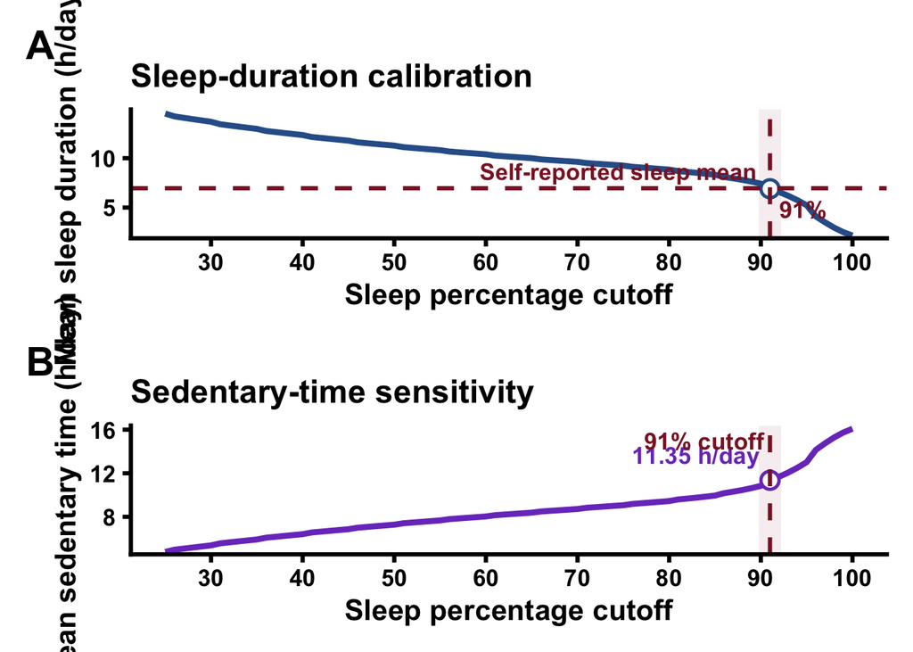

Figure 4. Sleep-cutoff calibration and sedentary-time sensitivity. Survey-weighted mean accelerometer-derived sleep duration and waking sedentary time are shown across candidate sleep-percentage cutoffs. Shaded bands indicate 95% confidence intervals. The vertical dashed line marks the selected 91% cutoff, calibrated to the self-reported sleep-duration benchmark.

```r
figure4_df <- results %>%
  mutate(
    sleep_ci_l = sleep_mean - qnorm(0.975) * sleep_se,
    sleep_ci_u = sleep_mean + qnorm(0.975) * sleep_se,
    sed_ci_l = sed_mean - qnorm(0.975) * sed_se,
    sed_ci_u = sed_mean + qnorm(0.975) * sed_se
  )

selected_row <- figure4_df %>%
  filter(cutoff == selected_cutoff) %>%
  slice(1)

fig4_theme <- theme_classic(base_size = 18) +
  theme(
    plot.title = element_text(face = "bold", size = 18, hjust = 0),
    plot.tag = element_text(face = "bold", size = 22),
    axis.title = element_text(face = "bold", size = 16),
    axis.text = element_text(face = "bold", size = 13, color = "black"),
    axis.line = element_line(linewidth = 1.1, color = "black"),
    axis.ticks = element_line(linewidth = 1.1, color = "black"),
    axis.ticks.length = unit(0.16, "cm"),
    legend.position = "none"
  )

sleep_panel <- ggplot(figure4_df, aes(x = cutoff, y = sleep_mean)) +
  annotate("rect", xmin = selected_cutoff - 1.25, xmax = selected_cutoff + 1.25, ymin = -Inf, ymax = Inf, fill = "#8B1E2D", alpha = 0.08) +
  geom_ribbon(aes(ymin = sleep_ci_l, ymax = sleep_ci_u), fill = "#D9E8F5", alpha = 0.95) +
  geom_line(color = "#2F5F98", linewidth = 1.55) +
  geom_point(data = selected_row, aes(y = sleep_mean), color = "#2F5F98", fill = "white", shape = 21, stroke = 1.3, size = 3.8) +
  geom_hline(yintercept = self_sleep_mean, color = "#8B1E2D", linewidth = 1.1, linetype = "dashed") +
  geom_vline(xintercept = selected_cutoff, color = "#8B1E2D", linewidth = 1.1, linetype = "dashed") +
  annotate("text", x = selected_cutoff - 1.4, y = self_sleep_mean, label = "Self-reported sleep mean", hjust = 1, vjust = -0.5, color = "#8B1E2D", fontface = "bold", size = 4.5) +
  annotate("text", x = selected_cutoff, y = selected_row$sleep_mean, label = paste0(selected_cutoff, "%"), hjust = -0.2, vjust = 1.7, color = "#8B1E2D", fontface = "bold", size = 4.6) +
  scale_x_continuous(breaks = seq(30, 100, 10), limits = c(25, 100)) +
  scale_y_continuous(limits = range(c(figure4_df$sleep_ci_l, figure4_df$sleep_ci_u, self_sleep_ci), na.rm = TRUE) + c(-0.15, 0.25), expand = expansion(mult = c(0, 0))) +
  labs(tag = "A", title = "Sleep-duration calibration", x = "Sleep percentage cutoff", y = "Mean sleep duration (h/day)") +
  fig4_theme

sed_panel <- ggplot(figure4_df, aes(x = cutoff, y = sed_mean)) +
  annotate("rect", xmin = selected_cutoff - 1.25, xmax = selected_cutoff + 1.25, ymin = -Inf, ymax = Inf, fill = "#8B1E2D", alpha = 0.08) +
  geom_ribbon(aes(ymin = sed_ci_l, ymax = sed_ci_u), fill = "#E8DFF4", alpha = 0.95) +
  geom_line(color = "#7B3FC6", linewidth = 1.55) +
  geom_point(data = selected_row, aes(y = sed_mean), color = "#7B3FC6", fill = "white", shape = 21, stroke = 1.3, size = 3.8) +
  geom_vline(xintercept = selected_cutoff, color = "#8B1E2D", linewidth = 1.1, linetype = "dashed") +
  annotate("text", x = selected_cutoff, y = selected_row$sed_mean, label = paste0(round(selected_row$sed_mean, 2), " h/day"), hjust = 1.08, vjust = -1.0, color = "#7B3FC6", fontface = "bold", size = 4.6) +
  annotate("text", x = selected_cutoff, y = max(figure4_df$sed_ci_u, na.rm = TRUE), label = paste0(selected_cutoff, "% cutoff"), hjust = 1.05, vjust = 1.3, color = "#8B1E2D", fontface = "bold", size = 4.6) +
  scale_x_continuous(breaks = seq(30, 100, 10), limits = c(25, 100)) +
  scale_y_continuous(limits = range(c(figure4_df$sed_ci_l, figure4_df$sed_ci_u), na.rm = TRUE) + c(-0.12, 0.18), expand = expansion(mult = c(0, 0))) +
  labs(tag = "B", title = "Sedentary-time sensitivity", x = "Sleep percentage cutoff", y = "Mean sedentary time (h/day)") +
  fig4_theme

figure4 <- sleep_panel / sed_panel + plot_layout(heights = c(1, 1))

ggsave("figures/cutoff_sensi.png", figure4, width = 9, height = 8, dpi = 600, bg = "white")
ggsave("figures/cutoff_sensi.pdf", figure4, width = 9, height = 8, bg = "white")
```

## Output Index

```r
tibble::tribble(
  ~Output, ~Path,
  "Table 1", "outputs/table1_wear_day_distribution.csv",
  "Table 2", "outputs/table2_study_comparison.csv",
  "Table 3", "outputs/table3_age_gender_sedentary.csv",
  "Table 4", "outputs/table4_race_bmi_sedentary.csv",
  "Figure 1", "figures/fig1.png",
  "Figure 2", "figures/figure2_hourly_daytype.png",
  "Figure 3", "figures/sedentary_distribution_with_24h_composition.png",
  "Figure 4", "figures/cutoff_sensi.png"
) %>%
  kable(caption = "Manuscript output index.")
```

Manuscript output index.

| Output | Path |
| --- | --- |
| Table 1 | outputs/table1_wear_day_distribution.csv |
| Table 2 | outputs/table2_study_comparison.csv |
| Table 3 | outputs/table3_age_gender_sedentary.csv |
| Table 4 | outputs/table4_race_bmi_sedentary.csv |
| Figure 1 | figures/fig1.png |
| Figure 2 | figures/figure2_hourly_daytype.png |
| Figure 3 | figures/sedentary_distribution_with_24h_composition.png |
| Figure 4 | figures/cutoff_sensi.png |